# Generate DTLZ2 PaletteViz

## Code to generate 5D DTLZ2 PaletteViz plots for EMO-2021

This notebook generates different plots for 5D DTLZ2 for EMO-2021 paper.

```python
%matplotlib notebook
%reload_ext autoreload
%autoreload 2

import sys
import os

import numpy as np
import matplotlib.pyplot as plt
from mpl_toolkits.mplot3d import Axes3D

plt.rcParams.update({'figure.max_open_warning': 0})
np.random.seed(123456)
```

### Get appropriate color codings and other markings

```python
sys.path.append('../../')
from vis.plotting.utils import resize_by_tradeoff, color_by_dist, color_by_cv, enhance_color

def load_props(path):
    r"""
    Load CV, Mu, Ik and S from path.
    """
    CV = None
    cvpathf = os.path.join(path, "datacv.csv")
    if os.path.exists(cvpathf):
        CV = np.loadtxt(cvpathf)

    # load the Mu values
    Mu = None
    mupathf = os.path.join(path, "mu.csv")
    if os.path.exists(mupathf):
        Mu = np.loadtxt(mupathf)

    # load the knee indices
    Ik = None
    kpathf = os.path.join(path, "muid.csv")
    if os.path.exists(kpathf):
        Ik = np.loadtxt(kpathf, dtype = int)

    return CV, Mu, Ik

def decide_size_color(CV, Mu, Ik):
    r"""
    Decide point-size and color from `CV`, `Mu` and `Ik`
    """
    # decide point-size
    S = 1
    if Mu is not None and Ik is not None:
        S = resize_by_tradeoff(Mu, k=Ik)

    # decide colors
    # C = default_color(F.shape[0], alpha=0.5)
    M = np.mean(F, axis=0)
    C, _ = color_by_dist(F, M, alpha=0.33)

    # if CV is available, use CV to color
    if CV is not None:
        C = color_by_cv(CV, alpha=0.33)

    # enhance knee points
    if Ik is not None:
        C = enhance_color(C, Ik, alpha=1.0)
    return S, C
```

### Load data

```python
pf,dim = 'dtlz2-nbi', '5d'

fullpathf = "./data/{0:s}/{1:s}/dataf.csv".format(pf, dim)
if os.path.exists(fullpathf):
    path, filenamef = os.path.split(fullpathf)
    dirs = path.split('/')
    frontname = dirs[-2]

    # load the front
    F = np.loadtxt(fullpathf, delimiter=',')
    print(fullpathf, F.shape, dirs, frontname)
```

```
./data/dtlz2-nbi/5d/dataf.csv (999, 5) ['.', 'data', 'dtlz2-nbi', '5d'] dtlz2-nbi
```

### Fig1: Plot 1000 points using PaletteViz in four levels.

Show point $f^{(0)}$ on the plot with a bright color (say, red or something, which is not in the paletteviz). This one should plotted in way so that all points are nicely visible.

```python
from scipy.spatial import cKDTree

# f0, f1, f2 end points
fp0 = [0.4473,0.4446,0.4461,0.4467,0.4515]
f0 = [0.4473,0.4446,0.4461,0.4467,0.4515]

fp1 = [0.2109,0.4234,0.4271,0.6429,0.4250]
f1 = [0.0000,0.0000,0.0000,1.0077,0.0000]

fp2 = [0.0000,0.1815,0.3668,0.5412,0.7345]
f2 = [0.0000,0.0000,0.0000,0.0000,1.0023]

fp3 = [0.0000,0.1696,0.3456,0.3368,0.8594]
f3 = [0.0000,0.1696,0.3456,0.3368,0.8594]


# build a tree
tree = None
tree = cKDTree(F)

# get the index for f0
_,fi = tree.query([fp0, f0, fp1, f1, fp2, f2, fp3, f3], k=1)
print(fi)
(ifp0,if0,ifp1,if1,ifp2,if2,ifp3,if3) = (np.array([fi[0]]), np.array([fi[1]]), np.array([fi[2]]), \
                                         np.array([fi[3]]), np.array([fi[4]]), np.array([fi[5]]), \
                                         np.array([fi[6]]), np.array([fi[7]]))
```

```
[315 315 766 407 650 133 205 205]
```

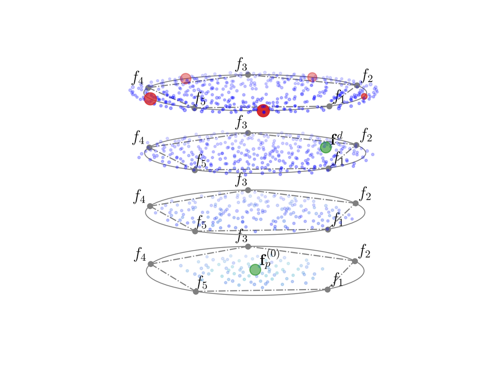

```
Plotting palette-star-viz.
Loading depth contours from ./data/dtlz2-nbi/5d/depth-cont-cvhull.csv.
```

```python
%matplotlib notebook
sys.path.append('../../')
from vis.plotting import paletteviz
from vis.plotting.paletteviz import camera_angles_star
from vis.plotting.utils import default_color, enhance_color

if F is not None:
    # load props
    CV, Mu, Ik = load_props(path)
    S,C = decide_size_color(CV, Mu, Ik)

    # change the color and size according to the requirements
    zi = np.array([ifp0[0], ifp3[0]])
    C = enhance_color(C, zi, c='g', alpha=1.0)
    S[zi] = 100.0

    pdffigpath = os.path.join(path, "palette-starviz-fig1.pdf")
    svgfigpath = os.path.join(path, "palette-starviz-fig1.svg")
    depth_contour_path = os.path.join(path, "depth-cont-cvhull.csv")
    with plt.rc_context({"text.usetex": True, "font.size": 12}):
        # plot
        ax = Axes3D(plt.figure())
        _,P = paletteviz.plot(F, ax=ax, depth_contours=depth_contour_path, mode='star', \
                        n_partitions=4, s=S, c=C, verbose=True, euler=(-40,15)) # camera_angles_star[pf][dim])
        # mark points
        ax.text(P[zi[0],0]+0.03, P[zi[0],1]+0.03, z=P[zi[0],2], s=r'$\mathbf{f}_p^{(0)}$', \
                ha='left', va='bottom', fontsize='large')
        ax.text(P[zi[1],0]+0.03, P[zi[1],1]+0.03, z=P[zi[1],2], s=r'$\mathbf{f}^d$', \
                ha='left', va='bottom', fontsize='large')

        # try to remove white space as much as possible
        plt.subplots_adjust(top=0.01, bottom=0, right=0.01, left=0, hspace=0, wspace=0)
        plt.margins(0,0,0)
        plt.gca().xaxis.set_major_locator(plt.NullLocator())
        plt.gca().yaxis.set_major_locator(plt.NullLocator())
        plt.gca().zaxis.set_major_locator(plt.NullLocator())

        # save the fig
        plt.savefig(pdffigpath, bbox_inches='tight', dpi=150, pad_inches=0)

        # show
        plt.show()
```

### Fig 2: On the another PaletteViz with same 1000 points, plot $f^{(1)}$ and join with an arrow from $f^{(0)}$.

Mark three equidistant intermediate points on the line:

- $p_1 = f^{(0)} + 0.25 (f^{(1)} - f^{(0)})$
- $p_2 = f^{(0)} + 0.50 (f^{(1)} - f^{(0)})$
- $p_3 = f^{(0)} + 0.75 (f^{(1)} - f^{(0)})$

Then, mark $z^{(1)}$ to $z^{(3)}$ points with another bright color. Join $z^{(1)}$ with the first intermediate point, and so on, to indicate that $z^{(1)}$ is obtained from p1 and so on. These points may be at different levels (if not, let me know, I need to add more points). Here, focus on near all these points.

```python
if tree is not None:
    # build a tree
    tree = cKDTree(F)

    z = [[0.2109,0.4234,0.4271,0.6429,0.4250], \
         [0.1740,0.0000,0.3478,0.8541,0.3455], \
         [0.1589,0.1575,0.1625,0.9483,0.1569]]

    # get the intermediate point indices
    _,zi = tree.query(z, k=1)
    zi = np.array([ifp0[0], zi[0], zi[1], zi[2], if1[0]])
    print(zi)
```

```
[315 766 313 416 407]
```

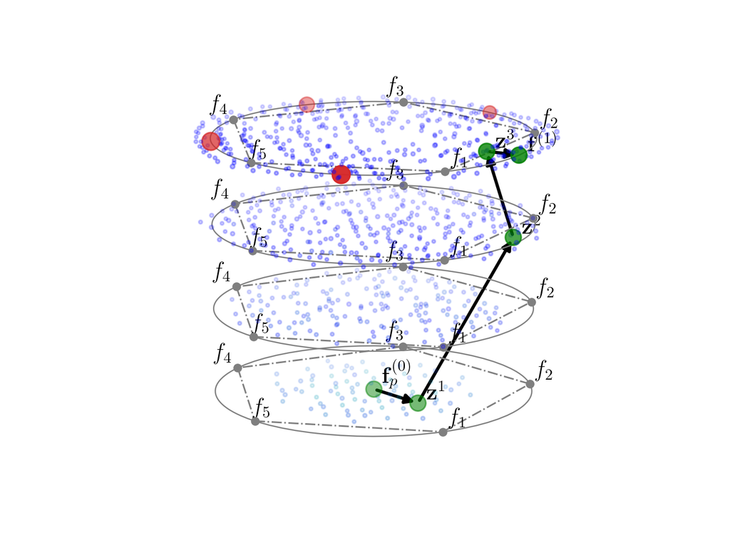

```
Plotting palette-star-viz.
Loading depth contours from ./data/dtlz2-nbi/5d/depth-cont-cvhull.csv.
```

```python
%matplotlib notebook
sys.path.append('../../')
from vis.plotting import paletteviz
from vis.plotting.paletteviz import camera_angles_star
from vis.plotting.utils import default_color, enhance_color, Arrow3D

if F is not None:
    # load props
    CV, Mu, Ik = load_props(path)
    S,C = decide_size_color(CV, Mu, Ik)

    # enhance intermediate points
    C = enhance_color(C, zi, alpha=1.0, c='g')
    S[zi] = 100.0
    # point labels
    labels = [r'$\mathbf{f}_p^{(0)}$', r'$\mathbf{z}^1$', r'$\mathbf{z}^2$', \
              r'$\mathbf{z}^3$', r'$\mathbf{f}^{(1)}$']
    # label pos
    lpos = [['left', 'bottom'], ['left', 'bottom'], ['left', 'bottom'], ['left', 'bottom'], ['left', 'bottom']]

    pdffigpath = os.path.join(path, "palette-starviz-fig2.pdf")
    svgfigpath = os.path.join(path, "palette-starviz-fig2.svg")
    depth_contour_path = os.path.join(path, "depth-cont-cvhull.csv")
    with plt.rc_context({"text.usetex": True, "font.size": 12}):
        ax = Axes3D(plt.figure())
        _,P = paletteviz.plot(F, ax=ax, depth_contours=depth_contour_path, mode='star', \
                        n_partitions=4, s=S, c=C, verbose=True, euler=(-25,20)) # camera_angles_star[pf][dim])

        # mark points
        for i in range(zi.shape[0]):
            ax.text(P[zi[i],0]+0.04, P[zi[i],1]+0.04, z=P[zi[i],2], s=labels[i], \
                    ha=lpos[i][0], va=lpos[i][1], fontsize='large')

        # draw arrows
        for i in range(zi.shape[0]-1):
            a = Arrow3D(\
                    [P[zi[i],0], P[zi[i+1],0]], \
                    [P[zi[i],1], P[zi[i+1],1]], \
                    [P[zi[i],2], P[zi[i+1],2]], \
                    mutation_scale = 12, lw = 2.0, \
                    arrowstyle = "-|>", color = 'black')
            ax.add_artist(a)

        # try to remove white space as much as possible
        plt.subplots_adjust(top=0.01, bottom=0, right=0.01, left=0, hspace=0, wspace=0)
        plt.margins(0,0,0)
        plt.gca().xaxis.set_major_locator(plt.NullLocator())
        plt.gca().yaxis.set_major_locator(plt.NullLocator())
        plt.gca().zaxis.set_major_locator(plt.NullLocator())

        # save the fig
        plt.savefig(pdffigpath, bbox_inches='tight', dpi=150, pad_inches=0)

        # show
        plt.show()
```

### Fig 3: On the another PaletteViz with same 1000 points, plot f^(2) and join with an arrow from f^(1).

Then, mark intermediate points

- $p_1 = f^{(1)} + 0.3333 (f^{(2)} - f^{(1)})$
- $p_2 = f^{(1)} + 0.6667 (f^{(2)} - f^{(1)})$
- $p_2 = f^{(1)} + 0.9999 (f^{(2)} - f^{(1)})$

and $z^{(1)}$ to $z^{(2)}$ points with another bright color. Join them. Then, plot the third iteration points $f^{(3)}$, join with $f^{(2)}$, and then mark two intermediate points $p_1$ and $p_2$ and their respective points $z^{(1)}$ and $z^{(2)}$ and join. Here also focus on the points.

```python
if tree is not None:
    z = [[0.0000,0.1815,0.3668,0.5412,0.7345], \
         [0.1548,0.0000,0.1527,0.3136,0.9245]]

    # get the intermediate point indices
    _,zi = tree.query(z, k=1)
    zi = np.array([ifp1[0], zi[0], zi[1], if2[0]])
    print(zi)
```

```
[766 650 111 133]
```

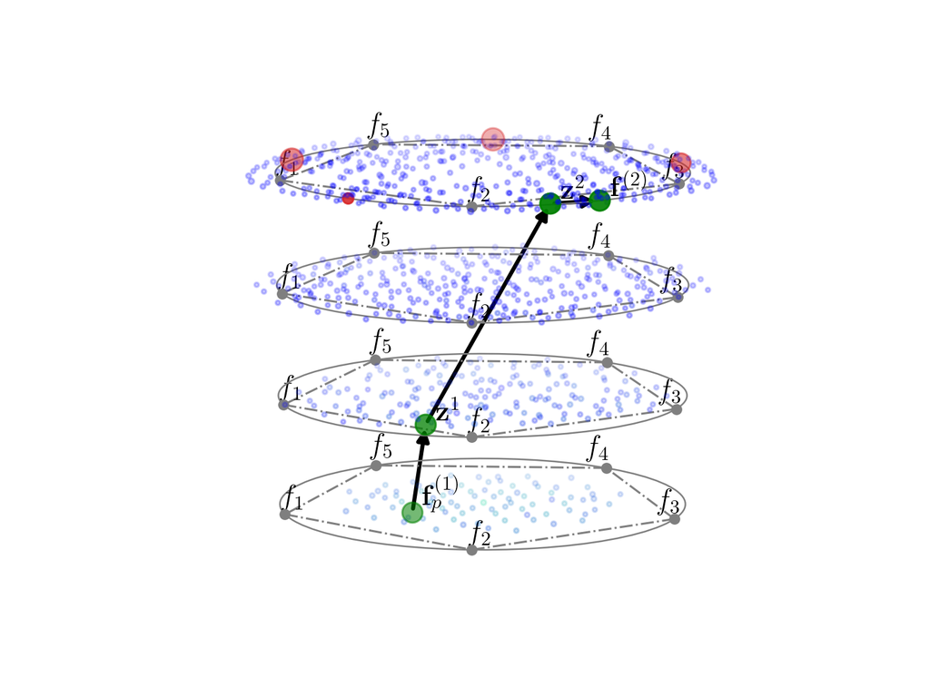

```
Plotting palette-star-viz.
Loading depth contours from ./data/dtlz2-nbi/5d/depth-cont-cvhull.csv.
```

```python
%matplotlib notebook
sys.path.append('../../')
from vis.plotting import paletteviz
from vis.plotting.paletteviz import camera_angles_star
from vis.plotting.utils import default_color, enhance_color, Arrow3D

if F is not None:
    # get the props
    CV, Mu, Ik = load_props(path)
    S,C = decide_size_color(CV, Mu, Ik)

    # enhance intermediate points
    C = enhance_color(C, zi, alpha=1.0, c='g')
    S[zi] = 100.0
    # point labels
    labels = [r'$\mathbf{f}_p^{(1)}$', r'$\mathbf{z}^1$', r'$\mathbf{z}^2$', r'$\mathbf{f}^{(2)}$']
    # label pos
    lpos = [['left', 'bottom'], ['left', 'bottom'], ['left', 'bottom'], ['left', 'bottom']]

    pdffigpath = os.path.join(path, "palette-starviz-fig3.pdf")
    svgfigpath = os.path.join(path, "palette-starviz-fig3.svg")
    depth_contour_path = os.path.join(path, "depth-cont-cvhull.csv")
    with plt.rc_context({"text.usetex": True, "font.size": 12}):
        # plot
        ax = Axes3D(plt.figure())
        _,P = paletteviz.plot(F, ax=ax, depth_contours=depth_contour_path, mode='star', \
                        n_partitions=4, s=S, c=C, verbose=True, euler=(75,15)) # camera_angles_star[pf][dim])

        # mark points
        for i in range(zi.shape[0]):
            ax.text(P[zi[i],0]-0.04, P[zi[i],1]+0.04, z=P[zi[i],2], s=labels[i], \
                    ha=lpos[i][0], va=lpos[i][1], fontsize='large')

        # draw arrows
        for i in range(zi.shape[0]-1):
            a = Arrow3D(\
                    [P[zi[i],0], P[zi[i+1],0]], \
                    [P[zi[i],1], P[zi[i+1],1]], \
                    [P[zi[i],2], P[zi[i+1],2]], \
                    mutation_scale = 12, lw = 2.0, \
                    arrowstyle = "-|>", color = 'black')
            ax.add_artist(a)

        # try to remove white space as much as possible
        plt.subplots_adjust(top=0.01, bottom=0, right=0.01, left=0, hspace=0, wspace=0)
        plt.margins(0,0,0)
        plt.gca().xaxis.set_major_locator(plt.NullLocator())
        plt.gca().yaxis.set_major_locator(plt.NullLocator())
        plt.gca().zaxis.set_major_locator(plt.NullLocator())

        # save the fig
        plt.savefig(pdffigpath, bbox_inches='tight', dpi=150, pad_inches=0)
        # plt.savefig(svgfigpath, bbox_inches='tight', dpi=150, pad_inches=0, format='svg')

        # show
        plt.show()
```

See the paper.

```python
if tree is not None:
    z = [[0.0000,0.0000,0.3227,0.4845,0.8131], \
         [0.0000,0.1696,0.3456,0.3368,0.8594]]

    # get the intermediate point indices
    _,zi = tree.query(z, k=1)
    zi = np.array([ifp2[0], zi[0], if3[0]])
    print(zi)
```

```
[650 280 205]
```

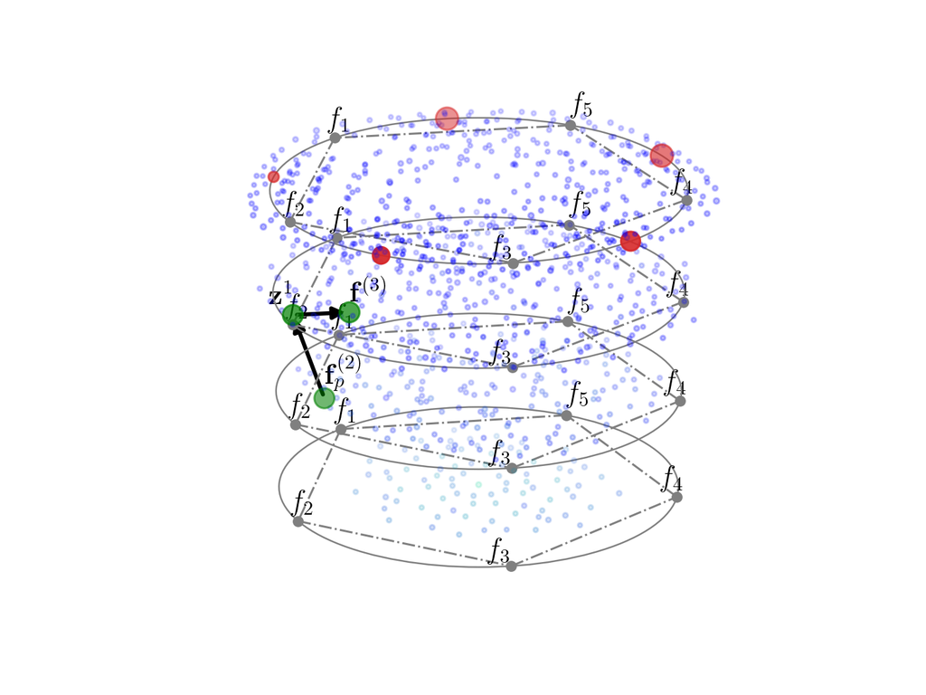

```
Plotting palette-star-viz.
Loading depth contours from ./data/dtlz2-nbi/5d/depth-cont-cvhull.csv.
```

```python
%matplotlib notebook
sys.path.append('../../')
from vis.plotting import paletteviz
from vis.plotting.paletteviz import camera_angles_star
from vis.plotting.utils import default_color, enhance_color, Arrow3D

if F is not None:
    # get the props
    CV, Mu, Ik = load_props(path)
    S,C = decide_size_color(CV, Mu, Ik)

    # enhance intermediate points
    C = enhance_color(C, zi, alpha=1.0, c='g')
    S[zi] = 100.0
    # point labels
    labels = [r'$\mathbf{f}_p^{(2)}$', r'$\mathbf{z}^1$', r'$\mathbf{f}^{(3)}$']
    # label pos
    lpos = [['left', 'bottom'], ['right', 'bottom'], ['left', 'bottom']]

    pdffigpath = os.path.join(path, "palette-starviz-fig4.pdf")
    svgfigpath = os.path.join(path, "palette-starviz-fig4.svg")
    depth_contour_path = os.path.join(path, "depth-cont-cvhull.csv")
    with plt.rc_context({"text.usetex": True, "font.size": 12}):
        # plot
        ax = Axes3D(plt.figure())
        _,P = paletteviz.plot(F, ax=ax, depth_contours=depth_contour_path, mode='star', \
                        n_partitions=4, s=S, c=C, verbose=True, euler=(135,30)) # camera_angles_star[pf][dim])

        # mark points
        for i in range(zi.shape[0]):
            ax.text(P[zi[i],0]+0.05, P[zi[i],1]-0.05, z=P[zi[i],2], s=labels[i], \
                    ha=lpos[i][0], va=lpos[i][1], fontsize='large')

        # draw arrows
        for i in range(zi.shape[0]-1):
            a = Arrow3D(\
                    [P[zi[i],0], P[zi[i+1],0]], \
                    [P[zi[i],1], P[zi[i+1],1]], \
                    [P[zi[i],2], P[zi[i+1],2]], \
                    mutation_scale = 12, lw = 2.0, \
                    arrowstyle = "-|>", color = 'black')
            ax.add_artist(a)

        # try to remove white space as much as possible
        plt.subplots_adjust(top=0.01, bottom=0, right=0.01, left=0, hspace=0, wspace=0)
        plt.margins(0.0,0.0,0.0)
        plt.gca().xaxis.set_major_locator(plt.NullLocator())
        plt.gca().yaxis.set_major_locator(plt.NullLocator())
        plt.gca().zaxis.set_major_locator(plt.NullLocator())

        # save the fig
        plt.savefig(pdffigpath, bbox_inches='tight', dpi=150, pad_inches=0)
        # plt.savefig(svgfigpath, bbox_inches='tight', dpi=150, pad_inches=0, format='svg')

        # show
        plt.show()
```

```python
if tree is not None:
    A = [[0.2109, 0.4234, 0.4271, 0.6429, 0.4250], \
         [0.0000, 0.1815, 0.3668, 0.5412, 0.7345], \
         [0.1548, 0.0000, 0.1527, 0.3136, 0.9245], \
         [0.0000, 0.1696, 0.3456, 0.3368, 0.8594]]

    A = np.array(A)
    _,ai = tree.query(A, k=1)
    print(ai)
```

```
[766 650 111 205]
```

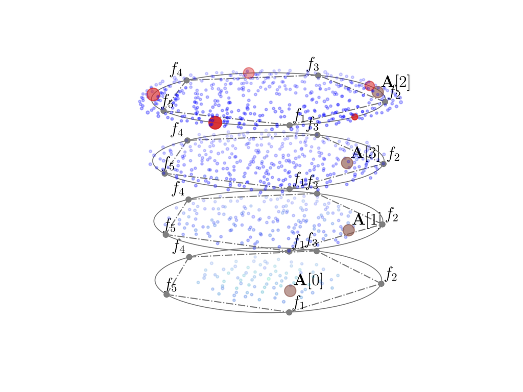

```
Plotting palette-star-viz.
Loading depth contours from ./data/dtlz2-nbi/5d/depth-cont-cvhull.csv.
```

```python
%matplotlib notebook
import matplotlib.colors as mc
sys.path.append('../../')
from vis.plotting import paletteviz
from vis.plotting.paletteviz import camera_angles_star
from vis.plotting.utils import default_color, enhance_color

if F is not None:
    # get the props
    CV, Mu, Ik = load_props(path)
    S,C = decide_size_color(CV, Mu, Ik)

    # enhance intermediate points
    C = enhance_color(C, ai, alpha=1.0, c=mc.TABLEAU_COLORS['tab:brown'])
    S[ai] = 100.0
    # point labels
    labels = [r'$\mathbf{A}[0]$', r'$\mathbf{A}[1]$', r'$\mathbf{A}[2]$', r'$\mathbf{A}[3]$']
    # label pos
    lpos = [['left', 'bottom'], ['left', 'bottom'], ['left', 'bottom'], ['left', 'bottom']]

    pdffigpath = os.path.join(path, "palette-starviz-fig5.pdf")
    svgfigpath = os.path.join(path, "palette-starviz-fig5.svg")
    depth_contour_path = os.path.join(path, "depth-cont-cvhull.csv")
    with plt.rc_context({"text.usetex": True, "font.size": 12}):
        # plot
        ax = Axes3D(plt.figure())
        _,P = paletteviz.plot(F, ax=ax, depth_contours=depth_contour_path, mode='star', \
                        n_partitions=4, s=S, c=C, verbose=True, euler=(-10,20)) # camera_angles_star[pf][dim])

        # mark points
        for i in range(ai.shape[0]):
            ax.text(P[ai[i],0]-0.04, P[ai[i],1]+0.04, z=P[ai[i],2], s=labels[i], \
                    ha=lpos[i][0], va=lpos[i][1], fontsize='large')

        # try to remove white space as much as possible
        plt.subplots_adjust(top=0.01, bottom=0, right=0.01, left=0, hspace=0, wspace=0)
        plt.margins(0.0,0.0,0.0)
        plt.gca().xaxis.set_major_locator(plt.NullLocator())
        plt.gca().yaxis.set_major_locator(plt.NullLocator())
        plt.gca().zaxis.set_major_locator(plt.NullLocator())

        # save the fig
        plt.savefig(pdffigpath, bbox_inches='tight', dpi=150, pad_inches=0)
        # plt.savefig(svgfigpath, bbox_inches='tight', dpi=150, pad_inches=0, format='svg')

        # show
        plt.show()
```